# homework5

Claire Whittington

2023-10-23

## (1) Exercise 1 – 3 pts

Convert the following to date or date/time objects.

- September 13, 2010.

```r
mdy("September 13, 2010")
```

```
## [1] "2010-09-13"
```

- Sept 13, 2010.

```r
str = "Sept 13, 2010"
modified_str = paste(str_sub(str, 1, 3) , str_sub(str, 6) )
# modified_str
mdy( modified_str )
```

```
## [1] "2010-09-13"
```

- Sep 13, 2010.

```r
mdy("Sep 13, 2010")
```

```
## [1] "2010-09-13"
```

- S 13, 2010. Comment on the month abbreviation needs.

COMMENT: I had to add “ep” after “S” since R prefers either 3 letters abbreviations or the full word

```r
str = "S 13, 2010"
modified_str = paste( paste( str_sub(str, 1, 1), "ep", sep =""),
                      str_sub(str, 3) )
#modified_str
mdy(modified_str)
```

```
## [1] "2010-09-13"
```

- 07-Dec-1941.

```r
str = "07-Dec-1941"
dmy(str)
```

```
## [1] "1941-12-07"
```

- 1 - 5 - 1998. Comment on why you might be wrong.

COMMENT: This format could either mean “January 5th, 1998” or “May 1st, 1998” depending on the user’s intentions

```r
str = "1-5-1998"
dmy(str)
```

```
## [1] "1998-05-01"
```

- 21-5-1998. Comment on why you know you are correct.

COMMENT: I know the format is day, month, year because there is no 21st month

```r
str = "21-5-1998"
dmy(str)
```

```
## [1] "1998-05-21"
```

- 2020-May-5 10:30 am

```r
str = "2020-May-5 10:30 am"
ymd_hm(str)
```

```
## [1] "2020-05-05 10:30:00 UTC"
```

- 2020-May-5 10:30 am PDT (ex Seattle)

```r
str = "2020-May-5 10:30 am PDT"
ymd_hm( str_sub(str, 1, 19), tz = "US/Pacific" )
```

```
## [1] "2020-05-05 10:30:00 PDT"
```

- 2020-May-5 10:30 am AST (ex Puerto Rico)

```r
str = "2020-May-5 10:30 am AST"
ymd_hm( str_sub(str, 1, 19), tz = "America/Glace_Bay" )
```

```
## [1] "2020-05-05 10:30:00 ADT"
```

## (2) Exercise 2 – 2 pts

Using just your date of birth (ex Sep 7, 1998) and today’s date calculate the following Write your code in a manner that the code will work on any date after you were born.:

```r
str = "Nov 16, 2002"
birthday = mdy(str)
birthday
```

```
## [1] "2002-11-16"
```

- Calculate the date of your 64th birthday.

```r
birthday + years(64)
```

```
## [1] "2066-11-16"
```

- Calculate your current age (in years). Hint: Check your age is calculated correctly if your birthday was yesterday and if it were tomorrow!

```r
today = lubridate::today()

current_age = as.period(birthday %--% today)
current_age
```

```
## [1] "20y 11m 10d 0H 0M 0S"
```

- Using your result in part (b), calculate the date of your next birthday.

```r
next_birthday = birthday + years( year(current_age) ) + years( 1 )
next_birthday
```

```
## [1] "2023-11-16"
```

- The number of days until your next birthday.

```r
days_till_birthday = next_birthday - today
days_till_birthday
```

```
## Time difference of 21 days
```

- The number of months and days until your next birthday.

```r
as.period(days_till_birthday)
```

```
## [1] "21d 0H 0M 0S"
```

## (3) Exercise 3 – 1 pt (show the code that answers the question, as well as the answer to the question).

Suppose you have arranged for a phone call to be at 3 pm on May 8, 2015 at Arizona time. However, the recipient will be in Auckland, NZ. What time will it be there?

ANSWER: It will be 10:00am in Auckland

```r
str <- "2015-May-8 3:00 pm MST"
arizona_time <- ymd_hm(str_sub(str, 1, 19), tz = "US/Arizona")
auckland_time <- with_tz(arizona_time, tzone = "Pacific/Auckland")

auckland_time
```

```
## [1] "2015-05-09 10:00:00 NZST"
```

## (4) Exercise 4 – 3 pts

```r
data.df = read.csv("~/Downloads/Pulliam_Airport_Weather_Station.csv")
tail(data.df)
```

```
##           STATION                             NAME LATITUDE LONGITUDE ELEVATION
## 25444 USW00003103 FLAGSTAFF PULLIAM AIRPORT, AZ US  35.1441 -111.6663    2134.5
## 25445 USW00003103 FLAGSTAFF PULLIAM AIRPORT, AZ US  35.1441 -111.6663    2134.5
## 25446 USW00003103 FLAGSTAFF PULLIAM AIRPORT, AZ US  35.1441 -111.6663    2134.5
## 25447 USW00003103 FLAGSTAFF PULLIAM AIRPORT, AZ US  35.1441 -111.6663    2134.5
## 25448 USW00003103 FLAGSTAFF PULLIAM AIRPORT, AZ US  35.1441 -111.6663    2134.5
## 25449 USW00003103 FLAGSTAFF PULLIAM AIRPORT, AZ US  35.1441 -111.6663    2134.5
##             DATE ACMH ACMH_ATTRIBUTES ACSH ACSH_ATTRIBUTES  AWND
## 25444 2019-09-10   NA                   NA                 15.21
## 25445 2019-09-11   NA                   NA                 12.97
## 25446 2019-09-12   NA                   NA                  6.04
## 25447 2019-09-13   NA                   NA                  2.68
## 25448 2019-09-14   NA                   NA                    NA
## 25449 2019-09-15   NA                   NA                    NA
##       AWND_ATTRIBUTES FMTM FMTM_ATTRIBUTES FRGT FRGT_ATTRIBUTES PGTM
```

[output cut: 97 more lines]

```r
attach(data.df)
```

```r
end = as.Date(max(DATE))
start = end - dyears(5)

period_5y_data = data.df[DATE >= start & DATE <= end,]
head(period_5y_data)
```

```
##           STATION                             NAME LATITUDE LONGITUDE ELEVATION
## 23623 USW00003103 FLAGSTAFF PULLIAM AIRPORT, AZ US  35.1441 -111.6663    2134.5
## 23624 USW00003103 FLAGSTAFF PULLIAM AIRPORT, AZ US  35.1441 -111.6663    2134.5
## 23625 USW00003103 FLAGSTAFF PULLIAM AIRPORT, AZ US  35.1441 -111.6663    2134.5
## 23626 USW00003103 FLAGSTAFF PULLIAM AIRPORT, AZ US  35.1441 -111.6663    2134.5
## 23627 USW00003103 FLAGSTAFF PULLIAM AIRPORT, AZ US  35.1441 -111.6663    2134.5
## 23628 USW00003103 FLAGSTAFF PULLIAM AIRPORT, AZ US  35.1441 -111.6663    2134.5
##             DATE ACMH ACMH_ATTRIBUTES ACSH ACSH_ATTRIBUTES AWND AWND_ATTRIBUTES
## 23623 2014-09-15   NA                   NA                 3.13             ,,W
## 23624 2014-09-16   NA                   NA                 3.13             ,,W
## 23625 2014-09-17   NA                   NA                 3.58             ,,W
## 23626 2014-09-18   NA                   NA                 3.13             ,,W
## 23627 2014-09-19   NA                   NA                 2.91             ,,W
## 23628 2014-09-20   NA                   NA                 3.36             ,,W
##       FMTM FMTM_ATTRIBUTES FRGT FRGT_ATTRIBUTES PGTM PGTM_ATTRIBUTES PRCP
```

[output cut: 97 more lines]

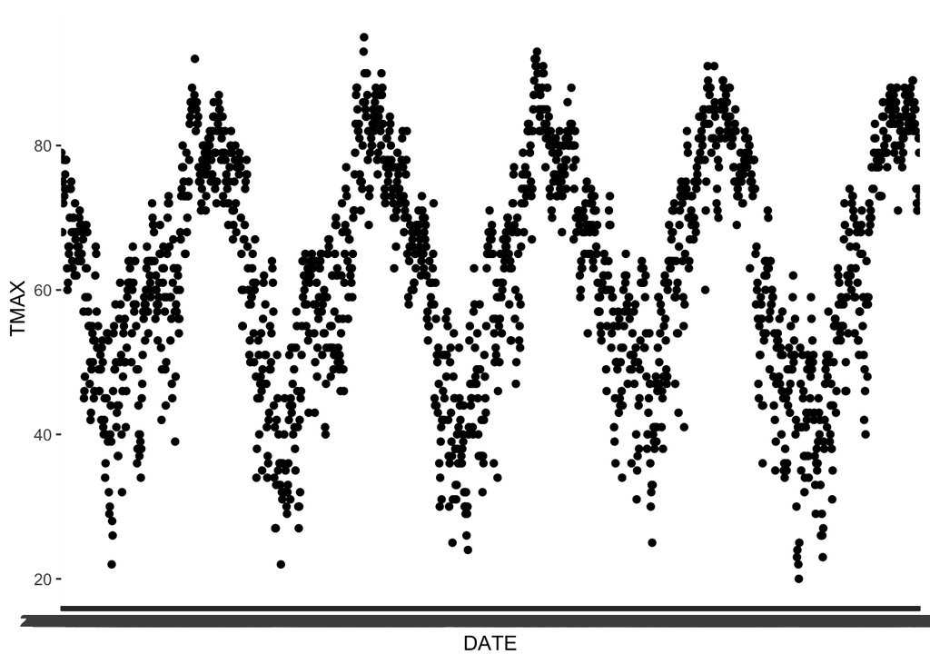

```r
ggplot(data = period_5y_data, aes(x = DATE, y = TMAX)) + geom_point()
```

## (5) Exercise 5 – 4 pts. Note there are 2 additional questions in part b.

It turns out there is some interesting periodicity regarding the number of births on particular days of the year

1. Using the mosaicData package, load the data set Births78 which records the number of children born on each day in the United States in 1978. Because this problem is intended to show how to calculate the information using the date, remove all the columns except date and births.

```r
library(mosaicData)
data(Births78)
attach(Births78)
head(Births78)
```

```
##         date births wday year month day_of_year day_of_month day_of_week
## 1 1978-01-01   7701  Sun 1978     1           1            1           1
## 2 1978-01-02   7527  Mon 1978     1           2            2           2
## 3 1978-01-03   8825  Tue 1978     1           3            3           3
## 4 1978-01-04   8859  Wed 1978     1           4            4           4
## 5 1978-01-05   9043  Thu 1978     1           5            5           5
## 6 1978-01-06   9208  Fri 1978     1           6            6           6
```

```r
birth_data <- select(Births78, date, births)
head(birth_data)
```

```
##         date births
## 1 1978-01-01   7701
## 2 1978-01-02   7527
## 3 1978-01-03   8825
## 4 1978-01-04   8859
## 5 1978-01-05   9043
## 6 1978-01-06   9208
```

2. Graph the number of births vs the date with date on the x-axis. What stands out to you? Why do you think we have this trend?

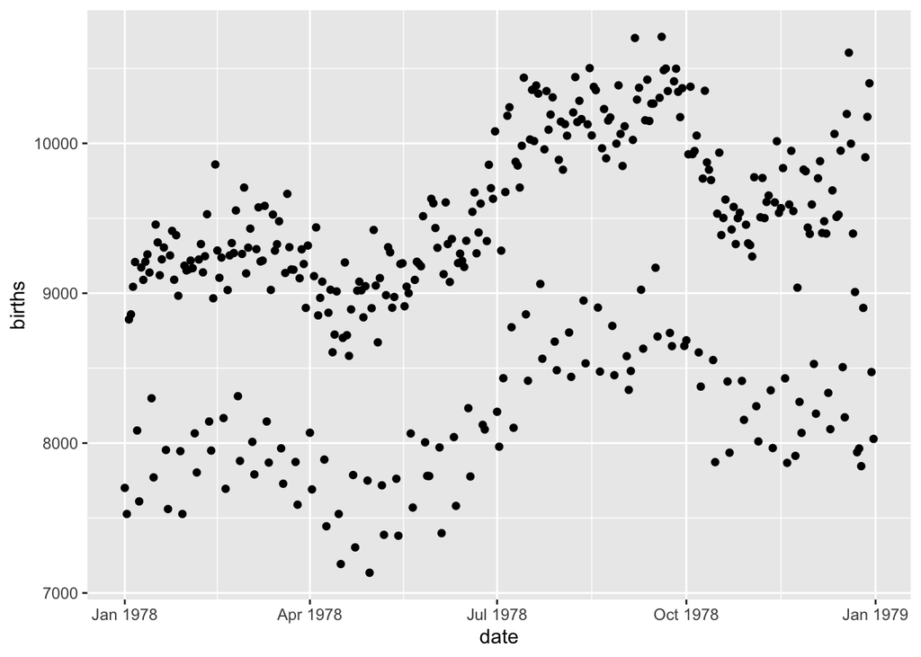

```r
P <- ggplot( birth_data, aes( x = date, y = births)) + geom_point()
P
```

Immediately I notice that there are more popular days and less popular days to have babies. Maybe Saturdays and Sundays are more popular because people don’t have work?

3. To test your assumption, we need to figure out the what day of the week each observation is. Use dplyr::mutate to add a new column named dow that is the day of the week (Monday, Tuesday, etc). This calculation will involve some function in the lubridate package and the date column.

```r
birth_data <- birth_data %>%
  mutate(dow = wday(date, label = TRUE, abbr = FALSE))
head(birth_data)
```

```
##         date births       dow
## 1 1978-01-01   7701    Sunday
## 2 1978-01-02   7527    Monday
## 3 1978-01-03   8825   Tuesday
## 4 1978-01-04   8859 Wednesday
## 5 1978-01-05   9043  Thursday
## 6 1978-01-06   9208    Friday
```

4. Plot the data with the point color being determined by the day of the week variable.

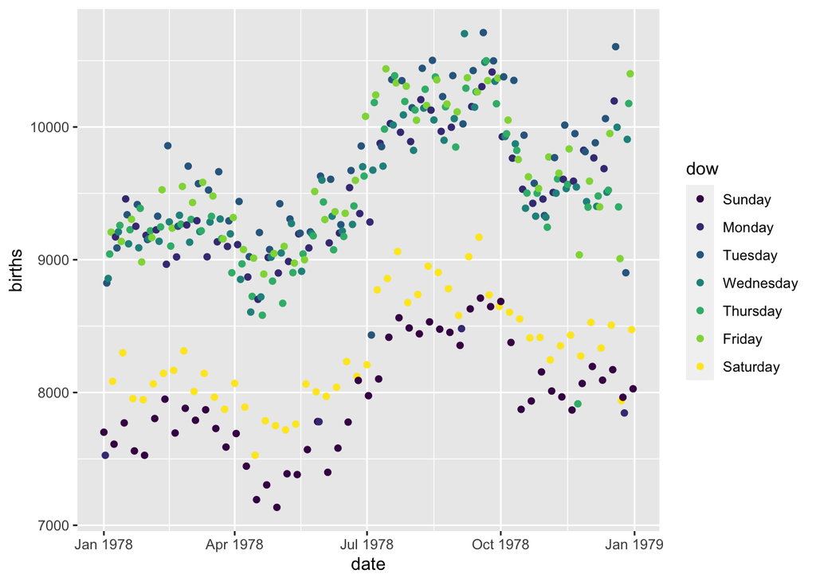

```r
ggplot(birth_data, aes(x=date, y=births, color = dow)) + geom_point()
```

My assumption was wrong - Weekdays are more popular to have babies. Perhaps this is because people don’t assume hospitals are open on weekends? Or maybe people want off work. Curious!

## (6) Turned in by the due date/time – 2 points.